# Intro to RNA-seq Analysis

## DESeq2 (pre-processing output)

The custom `DESeq2` script generates several plots, tables, and genelists organized into the following directories.

Outputs are organized into the `genelists` or `plots` folders.

```bash
analysis/deseq2/factor
├── genelists
└── plots
```

The `genelists` folder contains a summary of DEGs, all the deseq2 outputs (stored as an R object (RDS) and a CSV file, and DEGs with annotations.

```bash
$ ls -1 analysis/deseq2/factor/genelists/
Brain_6mo-Heart_6mo.deseq2_output.csv
Brain_6mo-Heart_6mo.DownDEG.annotated.csv
Brain_6mo-Heart_6mo.UpDEG.annotated.csv
Brain_6mo-Kidney_6mo.deseq2_output.csv
Brain_6mo-Kidney_6mo.DownDEG.annotated.csv
Brain_6mo-Kidney_6mo.UpDEG.annotated.csv
Brain_6mo-Liver_6mo.deseq2_output.csv
Brain_6mo-Liver_6mo.DownDEG.annotated.csv
Brain_6mo-Liver_6mo.UpDEG.annotated.csv
Brain_6mo-Lung_6mo.deseq2_output.csv
Brain_6mo-Lung_6mo.DownDEG.annotated.csv
Brain_6mo-Lung_6mo.UpDEG.annotated.csv
Brain_6mo-Muscle_6mo.deseq2_output.csv
Brain_6mo-Muscle_6mo.DownDEG.annotated.csv
Brain_6mo-Muscle_6mo.UpDEG.annotated.csv
Brain_6mo-Skin_6mo.deseq2_output.csv
Brain_6mo-Skin_6mo.DownDEG.annotated.csv
Brain_6mo-Skin_6mo.UpDEG.annotated.csv
deseq2_results.RDS
```

The `plots` folder contains a bar plot summarizing the number of DEGs, a PCA plot, and an enhanced volcano plot highlighting the DEGs.

```bash
$ ls -1 analysis/deseq2/factor/plots/*png
DEG_summary.pdf
DEG_summary.png
Enhancedvolcano_Brain_6mo-vs-Heart_6mo.pdf
Enhancedvolcano_Brain_6mo-vs-Heart_6mo.png
Enhancedvolcano_Brain_6mo-vs-Kidney_6mo.pdf
Enhancedvolcano_Brain_6mo-vs-Kidney_6mo.png
Enhancedvolcano_Brain_6mo-vs-Liver_6mo.pdf
Enhancedvolcano_Brain_6mo-vs-Liver_6mo.png
.
.
Heatmap_top25DEGs_Brain_6mo-vs-Heart_6mo.pdf
Heatmap_top25DEGs_Brain_6mo-vs-Kidney_6mo.pdf
Heatmap_top25DEGs_Brain_6mo-vs-Liver_6mo.pdf
Heatmap_top25DEGs_Brain_6mo-vs-Lung_6mo.pdf
Heatmap_top25DEGs_Brain_6mo-vs-Muscle_6mo.pdf
Heatmap_top25DEGs_Brain_6mo-vs-Skin_6mo.pdf
Heatmap_top25DEGs_Heart_6mo-vs-Kidney_6mo.pdf
.
.
PCA_files
PCA.html
PCA.pdf
PCA.png
upset_Down.pdf
upset_Down.png
upset_UporDown.pdf
upset_UporDown.png
upset_Up.pdf
upset_Up.png
```

**Summary table**

| Comparisons | Counts_Up_or_Down | Counts_Up | Counts_Down |
| --- | --- | --- | --- |
| Brain_6mo-Heart_6mo | 11898 | 6793 | 5105 |
| Brain_6mo-Kidney_6mo | 12042 | 6721 | 5321 |
| Brain_6mo-Liver_6mo | 12828 | 7602 | 5226 |
| Brain_6mo-Lung_6mo | 12199 | 6539 | 5660 |
| Brain_6mo-Muscle_6mo | 12139 | 6864 | 5275 |
| Brain_6mo-Skin_6mo | 12741 | 6401 | 6340 |
| Heart_6mo-Kidney_6mo | 9147 | 4591 | 4556 |
| Heart_6mo-Liver_6mo | 10015 | 5769 | 4246 |
| Heart_6mo-Lung_6mo | 9545 | 4047 | 5498 |
| Heart_6mo-Muscle_6mo | 5065 | 2527 | 2538 |
| Heart_6mo-Skin_6mo | 10355 | 4341 | 6014 |
| Kidney_6mo-Liver_6mo | 8280 | 5048 | 3232 |
| Kidney_6mo-Lung_6mo | 10316 | 4500 | 5816 |
| Kidney_6mo-Muscle_6mo | 9840 | 5087 | 4753 |
| Kidney_6mo-Skin_6mo | 10993 | 4592 | 6401 |
| Liver_6mo-Lung_6mo | 11757 | 4627 | 7130 |
| Liver_6mo-Muscle_6mo | 10593 | 4623 | 5970 |
| Liver_6mo-Skin_6mo | 11491 | 4225 | 7266 |
| Lung_6mo-Muscle_6mo | 11106 | 6338 | 4768 |
| Lung_6mo-Skin_6mo | 9827 | 4525 | 5302 |
| Muscle_6mo-Skin_6mo | 10437 | 4476 | 5961 |

**Summary plot**

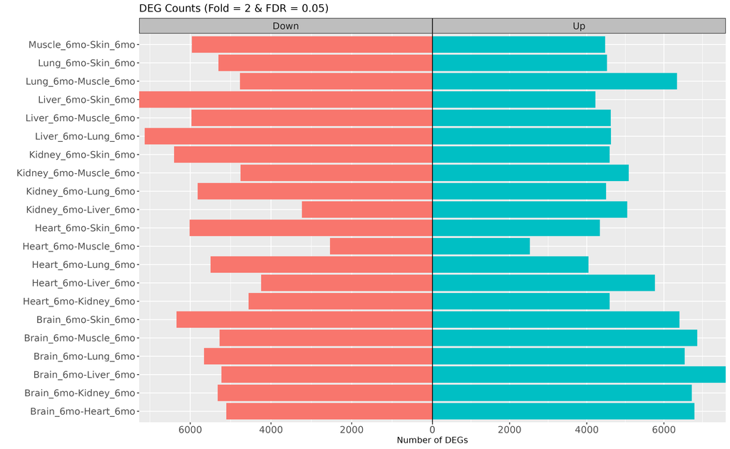

**PCA plot**

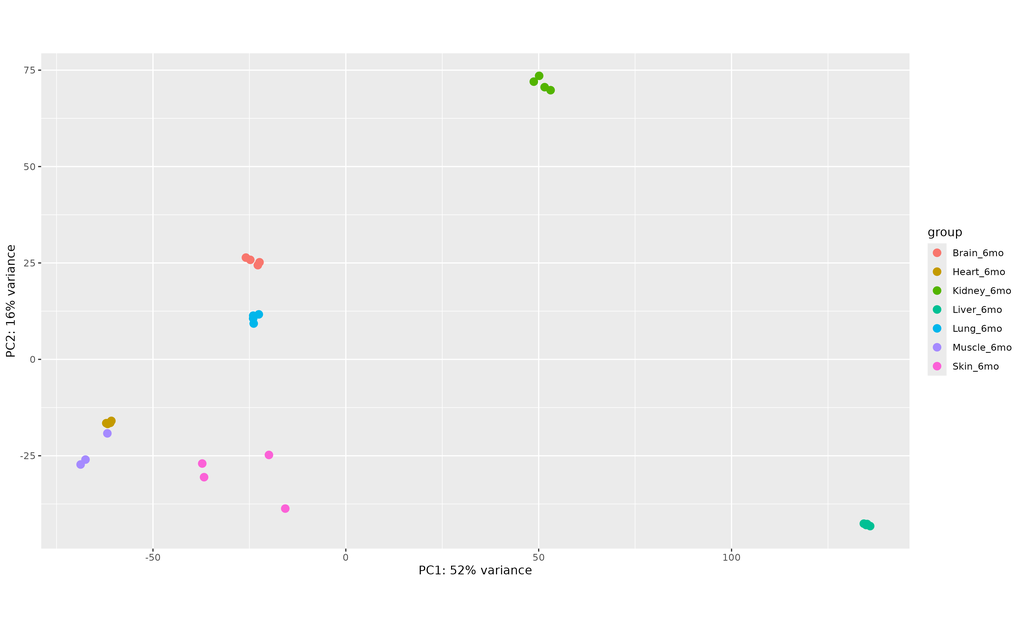

**Volcano plot (p < 0.05, l2fc > 1)**

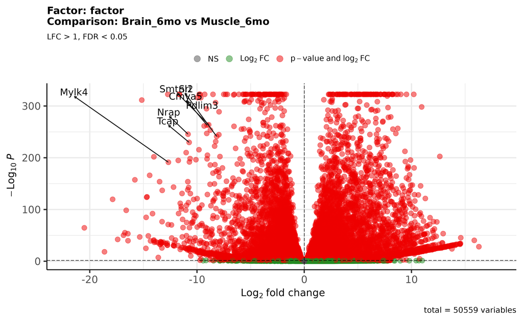

## Summary using MultiQC

`MultiQC` is used to generate a summary of the raw and processed data. The program aggregates all the log files from different programs (e.g., trim_galore, STAR) and provide a summary HTML file.

## Data Visualization with IGV

To inspect and examine your RNA-seq results, you can load the **BigWig** or **BAM** files into IGV.

Download the `.bam`, `.bam.bai`, and `.bw` files. The `.bam` files are quite large (> 1Gb) whereas the `.bw` files are smaller (Mb). These files can be loaded into IGV for visualization and inspection.

**Show IGV demonstration**

[IGV website](https://igv.org)

## Hands-On Session

We will have a hands-on practice with the analysis workflow using a Jupyter notebook.

## Feedback

Please take a few minutes to provide feedback for this workshop by filling out the workshop survey.

All responses are anonymous and will help to improve future workshops and training.

[Survey link](https://forms.gle/do2LWkURdzy8miG96)

# Additional Slides

## Downloading/Uploading files from the server

There will be times where you would want to see plots or access files generated on the cluster. For easier access, you can use an SFTP program with a GUI that connects to the server and provides direct access to those files.

There are several free GUI applications including [Filezilla](https://filezilla-project.org), [Cyberduck](https://cyberduck.io), [WinSCP](https://winscp.net/eng/download.php).

These applications are available for MacOS, WinOS, and Linux platforms.

Once you have the application installed, start up the program and follow the instructions to connect to a site.

[Click here](https://hpcc.ucr.edu/manuals/hpc_cluster/sharing/#authentication-with-passwordduo) for instructions to connect and authenticate to the cluster using `Filezilla` with password + DUO authentication.

## Submitting jobs on the cluster

For this workshop, we will submit jobs to the cluster (to run in the background).

Example job submission:

```bash
sbatch code/multiqc.sh
```

```bash
# Show all jobs from USER
squeue -u <USERNAME>
squeue --me

# Show specific job with JOBID
scontrol show job <JOBID>
```

To cancel a submitted job, use the JOBID.

```bash
# To delete a single job
scancel -i <JOBID>
scancel <JOBID>

# To delete all jobs for a user
scancel -u <USERNAME>
```

**Tip**

All submitted jobs will generate a log file (stored in the `log` folder) containing the JOBNAME_JOBID.log

- JOBNAME (e.g., fastqc, trim_galore)

You can take a look at the log file to see standard output/errors from running the script.

## Create conda environment

We will create a conda environment containing bioinformatics software packages not readily available on the cluster for data processing and analysis. This conda environment includes special R packages (e.g., EnhancedVolcano) and software (e.g., multiqc).

To create the conda environment:

```bash
sbatch code/create-conda-env.sh
```

**Note**: *This step can take anywhere from 25-45 minutes. However, it’s running in the background so we can come back to it later.*

To make sure the conda environment was created successfully, we can activate the conda environment:

```bash
conda activate DEG-analysis
```

You should now see the environment `(DEG-analysis)` next to your `$` prompt.

```bash
(DEG-analysis) $
```

**Tip**

To get out of the conda environment, type:

```bash
conda deactivate
```

The environment name in parentheses should now disappear.

## Setting up Bash for Jupyter notebook

We will install Bash for Jupyter notebook to enable running shell scripts within the notebook.

First, open a terminal session within the Jupyter Lab.

[figure not shown]

[figure not shown]

In the terminal, we’ll first create a conda environment and then install the `bash-kernel`.

- create a conda environment name jupyter-nb

```bash
conda create -n jupyter-nb python=3 ipython notebook
```

- activate the conda environment

```bash
conda activate jupyter-nb
```

- install the bash kernel

```bash
pip install bash_kernel
```

- Add bash to spec list

```bash
python -m bash_kernel.install
```

**Tip**

If the Bash kernel doesn’t appear as an option for your notebook, you can shutdown all kernels and try again